# Final R Reference Guide

Elyse McCormick

2022-12-10

# R Reference Guide

## Loading Data and Packages

**Loading data and packages**

**Loading packages**

Both require() and library() will load packages

```r
require(here)
library(palmerpenguins)
```

**Loading Data**

```r
ginkgo_dat = read.csv(
  here("data", "ginkgo_data_2022.csv")
)
head(ginkgo_dat)
```

```
##   site_id seeds_present max_width max_depth notch_depth petiole_length
## 1     216         FALSE        85        59          12             91
## 2     216         FALSE        72        54           0             56
## 3     216         FALSE        64        42           0             71
## 4     216         FALSE        76        48           0             44
## 5     216         FALSE        85        50           5             40
## 6     216         FALSE        75        46           7             50
```

## Data structures

**Data Structures**

**c() function**

The function c() combines or concatenates its arguments into a vector(a 1-dimensional data structure consisting of 1 or more elements). All of the elements must be of the same type, i.e. you can’t combine character and numeric types in the same call to c().

Here’s examples using numeric and character data types:

```r
## Create a vector of numbers:
num_vec  = c(1, 4, 8, 9, 13)

## Create a vector of characters:
char_vec = c("a", "fish", "data is cool")
```

I can show the contents of a vector by typing the name of the vector, or using the print() function.

```r
## Typing the name of the vector into the console prints the contents
num_vec
```

```
## [1]  1  4  8  9 13
```

```r
## The print() function accomplishes the same task:
print(char_vec)
```

```
## [1] "a"            "fish"         "data is cool"
```

**length() function**

The length() function can be used to get or set the length of vectors, lists, and factors, or any other R object that you’ve defined.

```r
length(num_vec)
```

```
## [1] 5
```

**matrix() function**

The matrix() function creates a matrix from a given set of data or values.

```r
# nrow is the number of rows you want
# ncol is the number of columsn you want
# byrow is a logical argument. If it's FALSE, then your matrix gets filled by the column. TRUE populates by row.

matrix(data = num_vec, nrow = 2, ncol = 2, byrow = FALSE)
```

```
##      [,1] [,2]
## [1,]    1    8
## [2,]    4    9
```

**data.frame()**

The data.frame() function creates a data frame of your data, which is tightly coupled collections of data in rows and columns that are used as the base data structure in R.

```r
ginkgo_data <- data.frame(ginkgo_dat)
```

**nrow() and ncol() functions**

Both nrow() and ncol() give you the number of rows or columns present in x.

```r
nrow(ginkgo_data)
```

```
## [1] 220
```

```r
ncol(ginkgo_data)
```

```
## [1] 6
```

**dim() function**

The dim() function gives the dimensions of an object or data frame.

```r
dim(ginkgo_data)
```

```
## [1] 220   6
```

## Subsetting

**Subsetting**

You can subset a dataframe by using the $ to pull out a specific column of data.

```r
ginkgo_data$max_width
```

```
##   [1]  85  72  64  76  85  75  72  81  87  87  94  92  70  84  61 102  82  64
##  [19]  53  66  69  55  56  64  60  59  57  53  68  56  75  63  82  83  60  67
##  [37]  75  92 110  54  77  59  51 100  92  77  99  62  80  86  63  79  91  72
##  [55]  64  53  71  61  70  93  75  87  86  87  95  88  85  95  95  52  84  74
##  [73]  87  76  57  92  94  79  97  50 100  97  63  96  97  70  83  80  85 100
##  [91] 112 115  83 106  95  80 120  76  50  90  94  69  93  59  60 103  95  90
## [109]  80  90 106  98  73  89  65  83 116  90  86 104  92 103 100  91 102  99
## [127]  98 104  80  68  62  77  86  72  70  63  72  65  69  67  35  67  63  71
## [145]  77  60  70  69  55  72  84 106  61 114  95  86  60  78  86  91  79  95
## [163]  72 102  72 107  95  91  94  90  98  63  58  67  92  75  74  73  73  94
## [181]  76  86  78  74  89  77  80  71  69  81  39  60  50  47  52  61  56  45
## [199]  64  42 103  84 118 120 100 111 104  94  78  70  92  48  79  91 111  44
## [217] 117  93 101 145
```

You can also subset by position using square brackets.

```r
# select first row of the ginkgo data
ginkgo_data[1,]
```

```
##   site_id seeds_present max_width max_depth notch_depth petiole_length
## 1     216         FALSE        85        59          12             91
```

```r
# select the element in row 2, column 3
ginkgo_data[2,3]
```

```
## [1] 72
```

```r
#select the 3rd column of the ginkgo data
ginkgo_data[,3]
```

```
##   [1]  85  72  64  76  85  75  72  81  87  87  94  92  70  84  61 102  82  64
##  [19]  53  66  69  55  56  64  60  59  57  53  68  56  75  63  82  83  60  67
##  [37]  75  92 110  54  77  59  51 100  92  77  99  62  80  86  63  79  91  72
##  [55]  64  53  71  61  70  93  75  87  86  87  95  88  85  95  95  52  84  74
##  [73]  87  76  57  92  94  79  97  50 100  97  63  96  97  70  83  80  85 100
##  [91] 112 115  83 106  95  80 120  76  50  90  94  69  93  59  60 103  95  90
## [109]  80  90 106  98  73  89  65  83 116  90  86 104  92 103 100  91 102  99
## [127]  98 104  80  68  62  77  86  72  70  63  72  65  69  67  35  67  63  71
## [145]  77  60  70  69  55  72  84 106  61 114  95  86  60  78  86  91  79  95
## [163]  72 102  72 107  95  91  94  90  98  63  58  67  92  75  74  73  73  94
## [181]  76  86  78  74  89  77  80  71  69  81  39  60  50  47  52  61  56  45
## [199]  64  42 103  84 118 120 100 111 104  94  78  70  92  48  79  91 111  44
## [217] 117  93 101 145
```

Finally, you can use the subset function to pull specific aspects of your data. For example, if I wanted only the information about Adelie penguins from the palmerpenguins dataset, I could do that using the subset function!

```r
require(palmerpenguins)
dat_pen = droplevels(subset(penguins, species == "Adelie"))
```

## Numerical Data Exploration

**Numerical Data Exploration**

**summary() function**

The summary() function will give you a basic overview of your selected object. In a data frame, it will give you the overview summary statistics for each column.

```r
summary(ginkgo_data)
```

```
##     site_id      seeds_present     max_width        max_depth
##  Min.   :  216   Mode :logical   Min.   : 35.00   Min.   : 24.0
##  1st Qu.: 3470   FALSE:180       1st Qu.: 67.00   1st Qu.: 45.0
##  Median : 4874   TRUE :40        Median : 80.00   Median : 53.0
##  Mean   : 5726                   Mean   : 79.95   Mean   : 53.1
##  3rd Qu.: 6719                   3rd Qu.: 93.00   3rd Qu.: 60.0
##  Max.   :12982                   Max.   :145.00   Max.   :125.0
##   notch_depth     petiole_length
##  Min.   : 0.000   Min.   : 13.00
##  1st Qu.: 0.000   1st Qu.: 45.00
##  Median : 2.000   Median : 58.00
##  Mean   : 5.977   Mean   : 59.51
##  3rd Qu.: 6.250   3rd Qu.: 71.00
##  Max.   :92.000   Max.   :126.00
```

**mean() function**

The mean() function will calculate the arithmetic mean of any group of numbers.

```r
mean(ginkgo_data$max_depth)
```

```
## [1] 53.09545
```

**sd() function**

The sd() function will calculate the standard deviation of any group of numbers.

```r
sd(ginkgo_data$max_depth)
```

```
## [1] 12.7281
```

## Graphical Data Exploration

**Graphical Data Exploration**

**Creating a Scatterplot**

To create a scatterplot, you need to use the plot() function. Within this, you can specify what you want the x and y axis to be by subsetting the data and calling them “x” and “y”. You can use ‘xlim’ and ‘ylim’ callss to specify a cutoff value for the x and y axes, here I called it ‘NULL’ since I didn’t want to truncate any values. The calls ‘xlab’ and ‘ylab’ allow you to name the axes. The argument ‘main’ allows you to name the title of the plot. ‘pch’ allows you to choose an icon to plot as a data point, ‘cex’ allows you to set the size of the font used, and ‘col’ allows you to change the color of the data points.

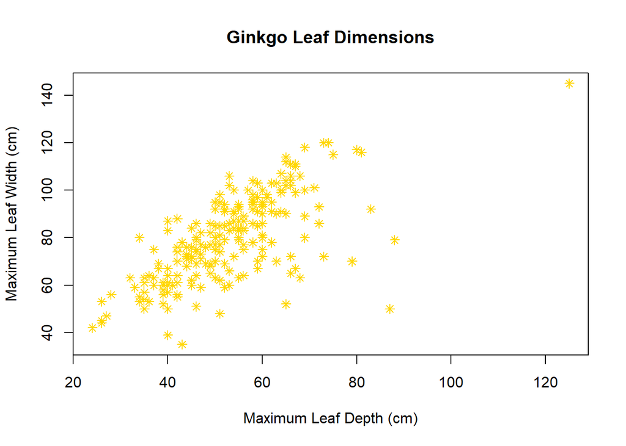

```r
plot(x = ginkgo_data$max_depth, y = ginkgo_data$max_width,
     xlim = NULL, ylim = NULL, xlab = "Maximum Leaf Depth (cm)",
     ylab = "Maximum Leaf Width (cm)", main = "Ginkgo Leaf Dimensions",
     pch = 8, cex = 1, col = "gold")
```

**Creating a Histogram**

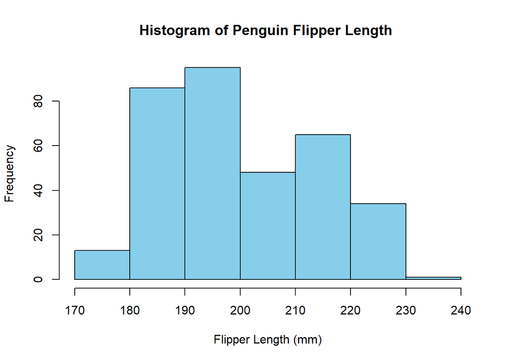

```r
require(palmerpenguins)
dat_pen <- palmerpenguins::penguins
hist(dat_pen$flipper_length_mm, breaks = 5, xlab = "Flipper Length (mm)", main = "Histogram of Penguin Flipper Length ",
     col = "skyblue")
```

**Creating a Boxplot**

The boxplot() function allows you to create a boxplot. First, you can specify which portion of your dataset you’d like to examine by subsetting a column. Then, you can specify the other aesthetic portions of the plot using the same methods as above. To make a conditional boxplot, simply note the dependent variable as explained by the independent variable by using a tilde (~)

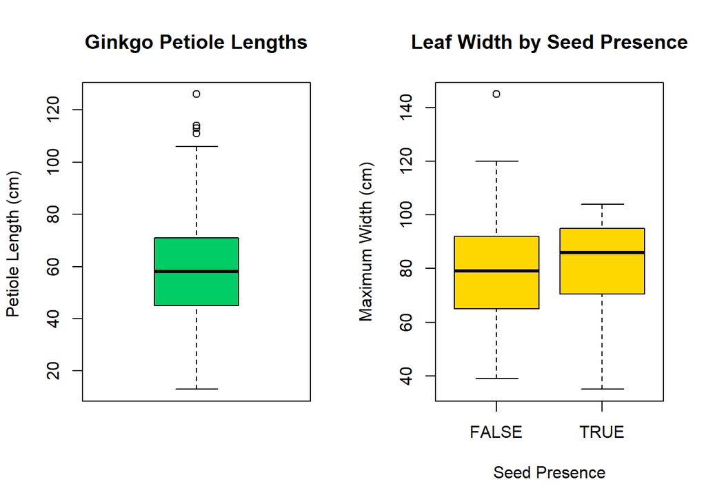

```r
par(mfrow = c(1,2))
boxplot(ginkgo_data$petiole_length, main = "Ginkgo Petiole Lengths", xlab = "", ylab = "Petiole Length (cm) ", col = "springgreen3")

boxplot(formula = max_width ~ seeds_present, data = ginkgo_data, main = "Leaf Width by Seed Presence",
        xlab = "Seed Presence", ylab = "Maximum Width (cm)", col = "gold")
```

**Creating a 2x2 Histogram Plot**

To make a multipanel plot, you can use the par(mfrow = ) argument to make a set of plot pairs. By listing what you need within the c function, you can make a 2 x 2 plot.

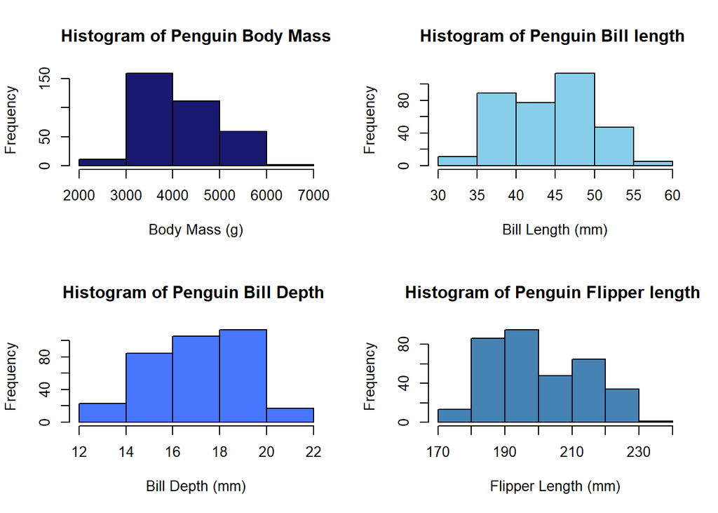

```r
par(mfrow = c(2,2))

hist(dat_pen$body_mass_g, breaks = 5, xlab = "Body Mass (g)", main = "Histogram of Penguin Body Mass",
     col = "midnightblue")

hist(dat_pen$bill_length_mm, breaks = 5, xlab = "Bill Length (mm)", main = "Histogram of Penguin Bill length ",
     col = "skyblue")

hist(dat_pen$bill_depth_mm, breaks = 5, xlab = "Bill Depth (mm)", main = "Histogram of Penguin Bill Depth ",
     col = "royalblue1")

hist(dat_pen$flipper_length_mm, breaks = 5, xlab = "Flipper Length (mm)", main = "Histogram of Penguin Flipper length ",
     col = "steelblue")
```

## Distribution Functions

**Distribution Functions**

There are four distribution functions for normal distributions. They are as follows:

dnorm(): the probability density

pnorm(): the cumulative probability density

qnorm(): the quantile function

rnorm(): function to generate random, normally-distributed numbers.

You can use these to create plots that show the distribution for the dataset.

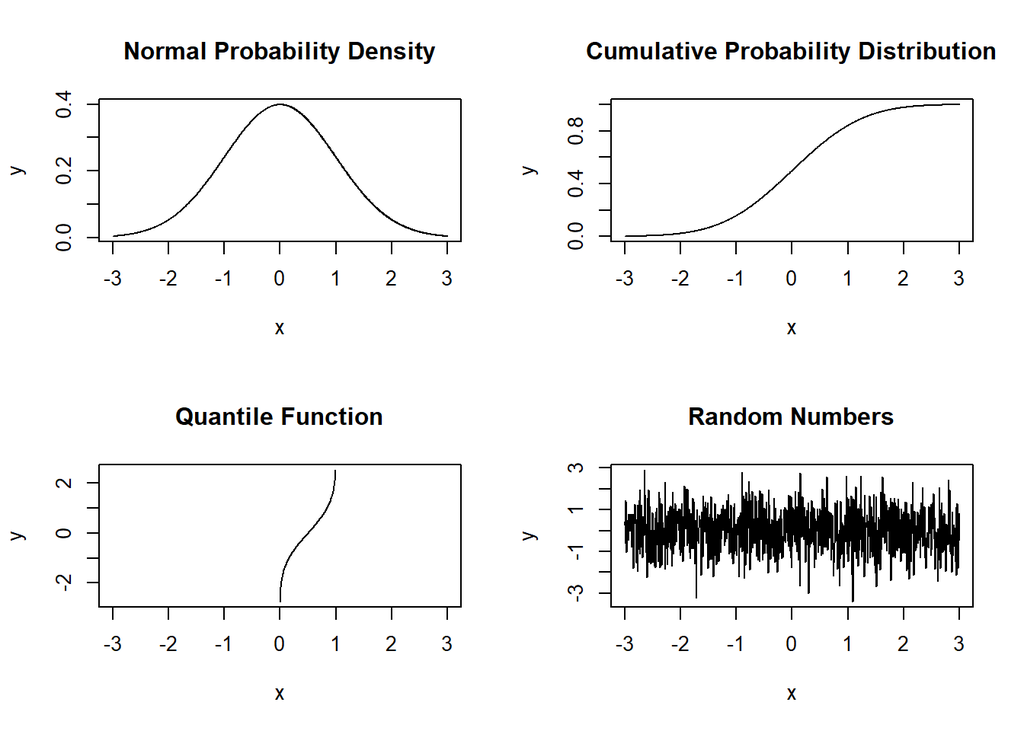

```r
par(mfrow = c(2,2))

x = seq(-3, 3, length.out = 1000)
y = dnorm(x)

plot(x, y, main = "Normal Probability Density", type = "l")

x = seq(-3, 3, length.out = 1000)
y = pnorm(x)

plot(x, y, main = "Cumulative Probability Distribution", type = "l")

x = seq(-3, 3, length.out = 1000)
y = qnorm(x)
plot(x, y, main = "Quantile Function", type = "l")

x = seq(-3, 3, length.out = 1000)
y = rnorm(x)

plot(x, y, main = "Random Numbers", type = "l")
```

There are also two distribution functions for binomial distributions.

pbinom(): This gives you the area under the left side of the tail of a binomial distribution. This also helps you calculate the probability of an event.

```r
#pbinom() used to find 7 or fewer successes, when the sample size is 30 items, and the probability is 30%
pbinom(7, size=30, prob=.3)
```

```
## [1] 0.2813767
```

```r
#qbinom() used to find the 25th quantile in 30 trials with a probability of 40%
qbinom(.25, size=30, prob=.4)
```

```
## [1] 10
```